# Lung cancer patients

### Gain ratio:

```r
C45Fit <- J48(myFormula, data = train_data)

## Display the confusion matrix for the training set.
table(predict(C45Fit), train_data$Level)
```

```
         Low Medium
  Low     63      0
  Medium   0      8
```

```r
## Display the C4.5 decision tree model details.
print(C45Fit)
```

```
J48 pruned tree
------------------

Alcohol.use <= 2: Low (63.0)
Alcohol.use > 2: Medium (8.0)

Number of Leaves  :     2

Size of the tree :  3
```

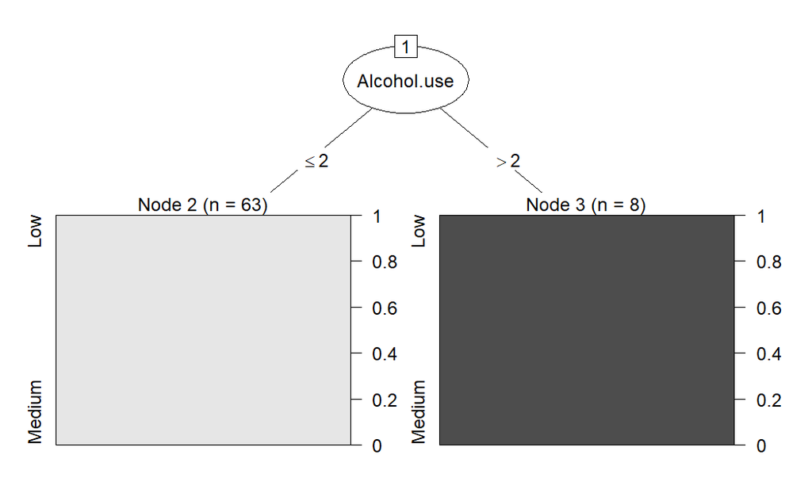

```r
## Plot the C4.5 decision tree model.
plot(C45Fit)
```

As seen in the graph the split is based on the “Alcohol use” attribute, if the value of “Alcohol use” is *less than or equal to 2*, the prediction is **“Low”** and there are 63 instances in the group. If the value of “Alcohol use” is *greater than 2*, the prediction is **“Medium”** and there are 8 instances in the group.

The tree has a size of 3, and has 2 leaves.

```r
## Predict on the testing set using the C4.5 decision tree model.
testPred <- predict(C45Fit, newdata = test_data)

## Evaluate model performance using confusionMatrix for gain ratio.
results <- confusionMatrix(testPred, test_data$Level, positive = "Low")
print(results)
```

```
Confusion Matrix and Statistics

          Reference
Prediction Low Medium
    Low     18      0
    Medium   0      2

               Accuracy : 1
                 95% CI : (0.8316, 1)
    No Information Rate : 0.9
    P-Value [Acc > NIR] : 0.1216

                  Kappa : 1

 Mcnemar's Test P-Value : NA

            Sensitivity : 1.0
            Specificity : 1.0
         Pos Pred Value : 1.0
         Neg Pred Value : 1.0
             Prevalence : 0.9
         Detection Rate : 0.9
   Detection Prevalence : 0.9
      Balanced Accuracy : 1.0

       'Positive' Class : Low
```

### Gini index:

```r
fit.tree <- rpart(myFormula, data = train_data, method = "class", cp = 0.008)

## Display the Gini decision tree model details.
print(fit.tree)
```

```
n= 71

node), split, n, loss, yval, (yprob)
      * denotes terminal node

1) root 71 8 Low (0.8873239 0.1126761)
  2) Alcohol.use< 3.5 63 0 Low (1.0000000 0.0000000) *
  3) Alcohol.use>=3.5 8 0 Medium (0.0000000 1.0000000) *
```

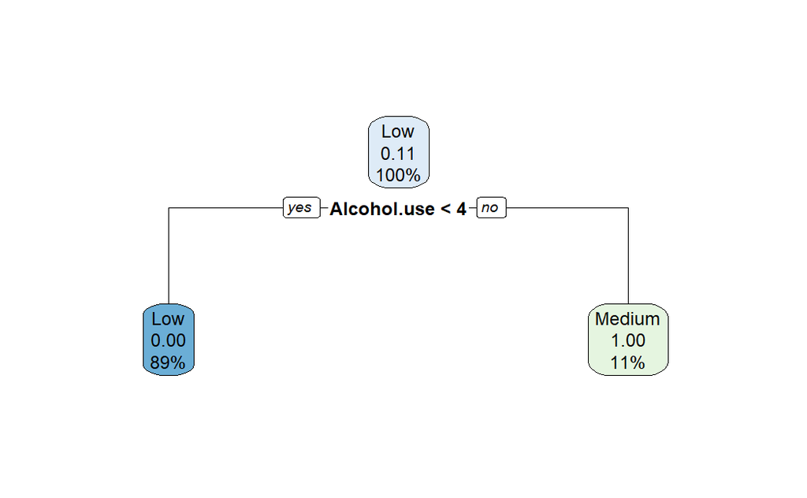

```r
## Plot the Gini decision tree model.
rpart.plot(fit.tree)
```

As seen in the graph the splitting attribute is “Alcohol use”. If “Alcohol use” is less than 4 , the prediction is **“Low”**. If “Alcohol use” is greater or equal to 4, the prediction is **“Medium”**.

```r
## Predict on the testing set using the Gini decision tree model.
testPred <- predict(fit.tree, newdata = test_data, type = "class")

## Evaluate model performance using confusionMatrix for Gini index.
results <- confusionMatrix(testPred, test_data$Level, positive = "Low")
print(results)
```

```
Confusion Matrix and Statistics

          Reference
Prediction Low Medium
    Low     18      0
    Medium   0      2

               Accuracy : 1
                 95% CI : (0.8316, 1)
    No Information Rate : 0.9
    P-Value [Acc > NIR] : 0.1216

                  Kappa : 1

 Mcnemar's Test P-Value : NA

            Sensitivity : 1.0
            Specificity : 1.0
         Pos Pred Value : 1.0
         Neg Pred Value : 1.0
             Prevalence : 0.9
         Detection Rate : 0.9
   Detection Prevalence : 0.9
      Balanced Accuracy : 1.0

       'Positive' Class : Low
```

### Table showing the results:

| 70% training set 30% testing set | IG | IG ratio | Gini index |
| --- | --- | --- | --- |
| Accuracy | 100% | 100% | 100% |
| Precision | 100% | 100% | 100% |
| Sensitivity | 100% | 100% | 100% |
| Specificity | 100% | 100% | 100% |